# 1031_Capstone_II

```python
!pip install bnlearn
```

[output not shown]

```python
pip install matplotlib==3.3.4
```

```
     |████████████████████████████████| 11.5 MB 3.9 MB/s
  Attempting uninstall: matplotlib
    Found existing installation: matplotlib 3.5.3
    Uninstalling matplotlib-3.5.3:
      Successfully uninstalled matplotlib-3.5.3
```

```python
import bnlearn as bn
from tabulate import tabulate
import pandas as pd
import numpy as np
import seaborn as sbn

%matplotlib inline
```

## Part 1 - Exploratory Data Analysis and Data Visualization

```python
df= pd.read_csv('/content/diabetes_012_health_indicators_BRFSS2015.csv')
df.head()
```

|  | Diabetes_012 | HighBP | HighChol | CholCheck | BMI | Smoker | Stroke | HeartDiseaseorAttack | PhysActivity | Fruits | ... | AnyHealthcare | NoDocbcCost | GenHlth | MentHlth | PhysHlth | DiffWalk | Sex | Age | Education | Income |
| --- | --- | --- | --- | --- | --- | --- | --- | --- | --- | --- | --- | --- | --- | --- | --- | --- | --- | --- | --- | --- | --- |
| 0 | 0.0 | 1.0 | 1.0 | 1.0 | 40.0 | 1.0 | 0.0 | 0.0 | 0.0 | 0.0 | ... | 1.0 | 0.0 | 5.0 | 18.0 | 15.0 | 1.0 | 0.0 | 9.0 | 4.0 | 3.0 |
| 1 | 0.0 | 0.0 | 0.0 | 0.0 | 25.0 | 1.0 | 0.0 | 0.0 | 1.0 | 0.0 | ... | 0.0 | 1.0 | 3.0 | 0.0 | 0.0 | 0.0 | 0.0 | 7.0 | 6.0 | 1.0 |
| 2 | 0.0 | 1.0 | 1.0 | 1.0 | 28.0 | 0.0 | 0.0 | 0.0 | 0.0 | 1.0 | ... | 1.0 | 1.0 | 5.0 | 30.0 | 30.0 | 1.0 | 0.0 | 9.0 | 4.0 | 8.0 |
| 3 | 0.0 | 1.0 | 0.0 | 1.0 | 27.0 | 0.0 | 0.0 | 0.0 | 1.0 | 1.0 | ... | 1.0 | 0.0 | 2.0 | 0.0 | 0.0 | 0.0 | 0.0 | 11.0 | 3.0 | 6.0 |
| 4 | 0.0 | 1.0 | 1.0 | 1.0 | 24.0 | 0.0 | 0.0 | 0.0 | 1.0 | 1.0 | ... | 1.0 | 0.0 | 2.0 | 3.0 | 0.0 | 0.0 | 0.0 | 11.0 | 5.0 | 4.0 |

5 rows × 22 columns

```python
df.info()
```

```
<class 'pandas.core.frame.DataFrame'>
RangeIndex: 35096 entries, 0 to 35095
Data columns (total 22 columns):
 #   Column                Non-Null Count  Dtype
---  ------                --------------  -----
 0   Diabetes_012          35096 non-null  float64
 1   HighBP                35096 non-null  float64
 2   HighChol              35096 non-null  float64
 3   CholCheck             35096 non-null  float64
 4   BMI                   35096 non-null  float64
 5   Smoker                35096 non-null  float64
 6   Stroke                35096 non-null  float64
 7   HeartDiseaseorAttack  35096 non-null  float64
 8   PhysActivity          35096 non-null  float64
 9   Fruits                35095 non-null  float64
 10  Veggies               35095 non-null  float64
 11  HvyAlcoholConsump     35095 non-null  float64
 12  AnyHealthcare         35095 non-null  float64
 13  NoDocbcCost           35095 non-null  float64
 14  GenHlth               35095 non-null  float64
 15  MentHlth              35095 non-null  float64
 16  PhysHlth              35095 non-null  float64
 17  DiffWalk              35095 non-null  float64
 18  Sex                   35095 non-null  float64
 19  Age                   35095 non-null  float64
 20  Education             35095 non-null  float64
 21  Income                35095 non-null  float64
dtypes: float64(22)
memory usage: 5.9 MB
```

```python
df_new= df.drop(["CholCheck", "PhysActivity", "AnyHealthcare", "NoDocbcCost", "GenHlth", "MentHlth", "PhysHlth", "DiffWalk", "Education", "Income"],axis=1)
df_new
```

|  | Diabetes_012 | HighBP | HighChol | BMI | Smoker | Stroke | HeartDiseaseorAttack | Fruits | Veggies | HvyAlcoholConsump | Sex | Age |
| --- | --- | --- | --- | --- | --- | --- | --- | --- | --- | --- | --- | --- |
| 0 | 0.0 | 1.0 | 1.0 | 40.0 | 1.0 | 0.0 | 0.0 | 0.0 | 1.0 | 0.0 | 0.0 | 9.0 |
| 1 | 0.0 | 0.0 | 0.0 | 25.0 | 1.0 | 0.0 | 0.0 | 0.0 | 0.0 | 0.0 | 0.0 | 7.0 |
| 2 | 0.0 | 1.0 | 1.0 | 28.0 | 0.0 | 0.0 | 0.0 | 1.0 | 0.0 | 0.0 | 0.0 | 9.0 |
| 3 | 0.0 | 1.0 | 0.0 | 27.0 | 0.0 | 0.0 | 0.0 | 1.0 | 1.0 | 0.0 | 0.0 | 11.0 |
| 4 | 0.0 | 1.0 | 1.0 | 24.0 | 0.0 | 0.0 | 0.0 | 1.0 | 1.0 | 0.0 | 0.0 | 11.0 |
| ... | ... | ... | ... | ... | ... | ... | ... | ... | ... | ... | ... | ... |
| 35091 | 0.0 | 1.0 | 1.0 | 36.0 | 1.0 | 0.0 | 0.0 | 1.0 | 1.0 | 0.0 | 0.0 | 10.0 |
| 35092 | 2.0 | 1.0 | 1.0 | 26.0 | 1.0 | 0.0 | 0.0 | 0.0 | 1.0 | 0.0 | 1.0 | 7.0 |
| 35093 | 2.0 | 0.0 | 0.0 | 33.0 | 0.0 | 0.0 | 0.0 | 1.0 | 1.0 | 0.0 | 0.0 | 8.0 |
| 35094 | 0.0 | 0.0 | 0.0 | 34.0 | 1.0 | 0.0 | 1.0 | 0.0 | 1.0 | 0.0 | 0.0 | 10.0 |
| 35095 | 0.0 | 1.0 | 0.0 | 31.0 | 0.0 | 0.0 | 0.0 | NaN | NaN | NaN | NaN | NaN |

35096 rows × 12 columns

## Feature Engeering

Transfer BMI to categorical

https://www.nhs.uk/common-health-questions/lifestyle/what-is-the-body-mass-index-bmi/

below 18.5 – you're in the underweight range between 18.5 and 24.9 – you're in the healthy weight range between 25 and 29.9 – you're in the overweight range between 30 and 39.9 – you're in the obese range

```python
df_new['BMI'] = df_new['BMI'].astype(float)
```

```python
df_new['BMI'] = pd.cut(x=df_new['BMI'],
                     bins=[0,18.5,25,30,100],
                     labels=['underweight', 'healthy weight', 'overweight',"obese"])
```

Transfer Age

```python
df_new['Age'] = pd.cut(x=df_new['Age'],
                     bins=[0,2.5,5.5,9.5,13.5],
                     labels=['Young Adult', 'Mid Adult', 'Old Adult',"Senior"])
```

```python
df_new.head()
```

|  | Diabetes_012 | HighBP | HighChol | BMI | Smoker | Stroke | HeartDiseaseorAttack | Fruits | Veggies | HvyAlcoholConsump | Sex | Age |
| --- | --- | --- | --- | --- | --- | --- | --- | --- | --- | --- | --- | --- |
| 0 | 0.0 | 1.0 | 1.0 | obese | 1.0 | 0.0 | 0.0 | 0.0 | 1.0 | 0.0 | 0.0 | Old Adult |
| 1 | 0.0 | 0.0 | 0.0 | healthy weight | 1.0 | 0.0 | 0.0 | 0.0 | 0.0 | 0.0 | 0.0 | Old Adult |
| 2 | 0.0 | 1.0 | 1.0 | overweight | 0.0 | 0.0 | 0.0 | 1.0 | 0.0 | 0.0 | 0.0 | Old Adult |
| 3 | 0.0 | 1.0 | 0.0 | overweight | 0.0 | 0.0 | 0.0 | 1.0 | 1.0 | 0.0 | 0.0 | Senior |
| 4 | 0.0 | 1.0 | 1.0 | healthy weight | 0.0 | 0.0 | 0.0 | 1.0 | 1.0 | 0.0 | 0.0 | Senior |

Transfer target variable

### Transfer necessary variables into booleans

```python
df_new.loc[(df_new.HighBP == 0),'HighBP']='False'
df_new.loc[(df_new.HighBP== 1),'HighBP']='True'
df_new.loc[(df_new.HighChol == 0),'HighChol']='False'
df_new.loc[(df_new.HighChol == 1),'HighChol']='True'
df_new.loc[(df_new.Smoker == 0),'Smoker']='False'
df_new.loc[(df_new.Smoker == 1),'Smoker']='True'
df_new.loc[(df_new.Stroke == 0),'Stroke']='False'
df_new.loc[(df_new.Stroke == 1),'Stroke']='True'
df_new.loc[(df_new.HeartDiseaseorAttack == 0),'HeartDiseaseorAttack']='False'
df_new.loc[(df_new.HeartDiseaseorAttack == 1),'HeartDiseaseorAttack']='True'
df_new.loc[(df_new.Fruits == 0),'Fruits']='False'
df_new.loc[(df_new.Fruits == 1),'Fruits']='True'
df_new.loc[(df_new.Veggies == 0),'Veggies']='False'
df_new.loc[(df_new.Veggies == 1),'Veggies']='True'
df_new.loc[(df_new.HvyAlcoholConsump == 0),'HvyAlcoholConsump']='False'
df_new.loc[(df_new.HvyAlcoholConsump == 1),'HvyAlcoholConsump']='True'
df_new.loc[(df_new.Sex == 0),'Sex']='fem'
df_new.loc[(df_new.Sex == 1),'Sex']='male'
```

```python
df_new.loc[(df_new.Diabetes_012 == 1),'Diabetes_012']=0
df_new.loc[(df_new.Diabetes_012 == 2),'Diabetes_012']=1
```

```python
df_new.head()
```

|  | Diabetes_012 | HighBP | HighChol | BMI | Smoker | Stroke | HeartDiseaseorAttack | Fruits | Veggies | HvyAlcoholConsump | Sex | Age |
| --- | --- | --- | --- | --- | --- | --- | --- | --- | --- | --- | --- | --- |
| 0 | 0.0 | True | True | obese | True | False | False | False | True | False | fem | Old Adult |
| 1 | 0.0 | False | False | healthy weight | True | False | False | False | False | False | fem | Old Adult |
| 2 | 0.0 | True | True | overweight | False | False | False | True | False | False | fem | Old Adult |
| 3 | 0.0 | True | False | overweight | False | False | False | True | True | False | fem | Senior |
| 4 | 0.0 | True | True | healthy weight | False | False | False | True | True | False | fem | Senior |

Review data dimension and data type for each feature

```python
def df_summary(df,head_size = 5, show_info = True):
    '''print df summary statistics to screen'''
    display(df.shape)
    display(df.head(head_size))
    if show_info:
        display(df.info())

df_summary(df_new)
```

```
(35096, 12)
```

|  | Diabetes_012 | HighBP | HighChol | BMI | Smoker | Stroke | HeartDiseaseorAttack | Fruits | Veggies | HvyAlcoholConsump | Sex | Age |
| --- | --- | --- | --- | --- | --- | --- | --- | --- | --- | --- | --- | --- |
| 0 | 0.0 | True | True | obese | True | False | False | False | True | False | fem | Old Adult |
| 1 | 0.0 | False | False | healthy weight | True | False | False | False | False | False | fem | Old Adult |
| 2 | 0.0 | True | True | overweight | False | False | False | True | False | False | fem | Old Adult |
| 3 | 0.0 | True | False | overweight | False | False | False | True | True | False | fem | Senior |
| 4 | 0.0 | True | True | healthy weight | False | False | False | True | True | False | fem | Senior |

```
<class 'pandas.core.frame.DataFrame'>
RangeIndex: 35096 entries, 0 to 35095
Data columns (total 12 columns):
 #   Column                Non-Null Count  Dtype
---  ------                --------------  -----
 0   Diabetes_012          35096 non-null  float64
 1   HighBP                35096 non-null  object
 2   HighChol              35096 non-null  object
 3   BMI                   35096 non-null  category
 4   Smoker                35096 non-null  object
 5   Stroke                35096 non-null  object
 6   HeartDiseaseorAttack  35096 non-null  object
 7   Fruits                35095 non-null  object
 8   Veggies               35095 non-null  object
 9   HvyAlcoholConsump     35095 non-null  object
 10  Sex                   35095 non-null  object
 11  Age                   35095 non-null  category
dtypes: category(2), float64(1), object(9)
memory usage: 2.7+ MB
```

```
None
```

Identify the unique number of values of each feature in the dataset

```python
df_new.nunique()
```

```
Diabetes_012            2
HighBP                  2
HighChol                2
BMI                     4
Smoker                  2
Stroke                  2
HeartDiseaseorAttack    2
Fruits                  2
Veggies                 2
HvyAlcoholConsump       2
Sex                     2
Age                     4
dtype: int64
```

Check for missing values

```python
df_new.isnull().sum()
```

```
Diabetes_012            0
HighBP                  0
HighChol                0
BMI                     0
Smoker                  0
Stroke                  0
HeartDiseaseorAttack    0
Fruits                  1
Veggies                 1
HvyAlcoholConsump       1
Sex                     1
Age                     1
dtype: int64
```

Review the data summary statistics

```python
df_new.describe()
```

|  | Diabetes_012 |
| --- | --- |
| count | 35096.000000 |
| mean | 0.133292 |
| std | 0.339894 |
| min | 0.000000 |
| 25% | 0.000000 |
| 50% | 0.000000 |
| 75% | 0.000000 |
| max | 1.000000 |

```python
import matplotlib.pyplot as plt
```

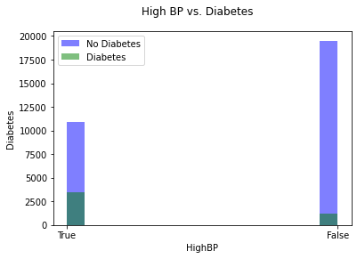

```python
fig, ax = plt.subplots()

ax.hist(df_new[df_new["Diabetes_012"]==0]["HighBP"], bins=15, alpha=0.5, color="blue", label="No Diabetes")
ax.hist(df_new[df_new["Diabetes_012"]==1]["HighBP"], bins=15, alpha=0.5, color="green", label="Diabetes")

ax.set_xlabel("HighBP")
ax.set_ylabel("Diabetes")

fig.suptitle("High BP vs. Diabetes")

ax.legend();
```

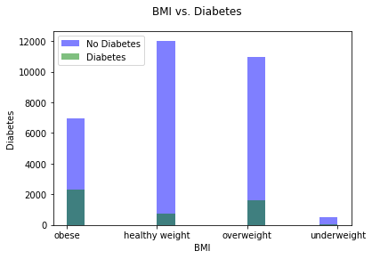

```python
fig, ax = plt.subplots()

ax.hist(df_new[df_new["Diabetes_012"]==0]["BMI"], bins=15, alpha=0.5, color="blue", label="No Diabetes")
ax.hist(df_new[df_new["Diabetes_012"]==1]["BMI"], bins=15, alpha=0.5, color="green", label="Diabetes")

ax.set_xlabel("BMI")
ax.set_ylabel("Diabetes")

fig.suptitle("BMI vs. Diabetes")

ax.legend();
```

[output not shown]

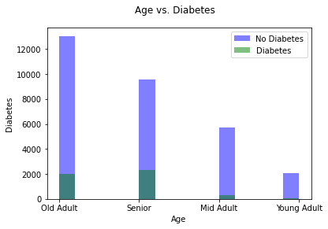

```python
fig, ax = plt.subplots()

ax.hist(df_new[df_new["Diabetes_012"]==0]["Age"].dropna(), bins=15, alpha=0.5, color="blue", label="No Diabetes")
ax.hist(df_new[df_new["Diabetes_012"]==1]["Age"].dropna(), bins=15, alpha=0.5, color="green", label="Diabetes")

ax.set_xlabel("Age")
ax.set_ylabel("Diabetes")

fig.suptitle("Age vs. Diabetes")

ax.legend();
```

```python
import numpy as np
```

```python
df_new.columns
```

```
Index(['Diabetes_012', 'HighBP', 'HighChol', 'BMI', 'Smoker', 'Stroke',
       'HeartDiseaseorAttack', 'Fruits', 'Veggies', 'HvyAlcoholConsump', 'Sex',
       'Age'],
      dtype='object')
```

Search for intial structure from algorithms

```python
!pip install pgmpy
```

```python
import networkx as nx
from pgmpy.models import BayesianNetwork
```

```python
from itertools import combinations

import networkx as nx
from sklearn.metrics import f1_score

from pgmpy.estimators import PC, HillClimbSearch, ExhaustiveSearch
from pgmpy.estimators import K2Score
from pgmpy.utils import get_example_model
from pgmpy.sampling import BayesianModelSampling
```

Train Test Split

```python
X = df_new.drop('Diabetes_012',axis=1)
y = df_new['Diabetes_012']
```

```python
from sklearn.model_selection import train_test_split
X_train, X_test, y_train, y_test = train_test_split(X, y, test_size=0.2, random_state=101)
```

```python
df_train=pd.concat([X_train,y_train],axis=1)
```

```python
df_train.head()
```

|  | HighBP | HighChol | BMI | Smoker | Stroke | HeartDiseaseorAttack | Fruits | Veggies | HvyAlcoholConsump | Sex | Age | Diabetes_012 |
| --- | --- | --- | --- | --- | --- | --- | --- | --- | --- | --- | --- | --- |
| 4480 | False | False | healthy weight | False | False | False | False | True | False | male | Mid Adult | 0.0 |
| 10754 | True | True | obese | True | False | False | True | True | False | fem | Senior | 0.0 |
| 23396 | True | True | overweight | True | False | False | True | True | False | fem | Old Adult | 0.0 |
| 21942 | True | True | overweight | False | False | False | True | True | False | male | Senior | 0.0 |
| 7353 | False | False | overweight | False | False | False | True | True | False | fem | Senior | 0.0 |

```python
df_train.to_csv("df_train.csv")
```

```python
df_new.to_csv("df_new.csv")
```

### Learning Structure from Data

### Hillclimbsearch(PGMPY)

```python
scoring_method = K2Score(data=df_train)
est_hc = HillClimbSearch(data=df_train)
estimated_model_hc = est_hc.estimate(
    scoring_method=scoring_method, max_indegree=4, max_iter=int(1e4)
)
```

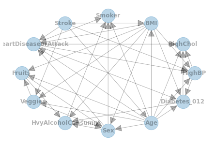

```python
dag_hc = estimated_model_hc
nx.draw_circular(
    dag_hc, with_labels=True, arrowsize=30, node_size=800, alpha=0.3, font_weight="bold"
)
plt.show()
```

```python
print(estimated_model_hc.edges())
```

[output not shown]

### Chow-Liu algorithm（Pgmpy）

```python
from pgmpy.estimators import TreeSearch

# learn graph structure
est_cl = TreeSearch(df_train, root_node="BMI")
```

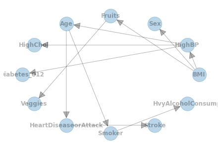

```python
dag_cl = est_cl.estimate(estimator_type="chow-liu")
nx.draw_circular(
    dag_cl, with_labels=True, arrowsize=30, node_size=800, alpha=0.3, font_weight="bold"
)
plt.show()
```

### TAN structure(pgmpy)

```python
est_tan = TreeSearch(df_train, root_node="Diabetes_012")
```

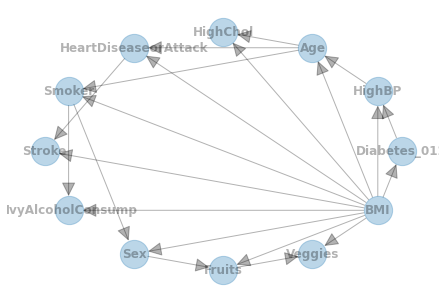

```python
dag_tan = est_tan.estimate(estimator_type="tan", class_node="BMI")
nx.draw_circular(
    dag_tan, with_labels=True, arrowsize=30, node_size=800, alpha=0.3, font_weight="bold"
)
plt.show()
```

#### Hillclimbsearch

Hillclimbsearch is a heuristic search approach that can be used with larger number of nodes. It implements a greedy local search that starts from the DAG “start” (default: disconnected DAG) and proceeds by iteratively performing single-edge manipulations that maximally increase the score. The search terminates once a local maximum is found.

```
[bnlearn] >Warning: Computing DAG with 12 nodes can take a very long time!
[bnlearn] >Computing best DAG using [hc]
[bnlearn] >Set scoring type at [bic]
DAG with 12 nodes and 38 edges
[bnlearn]> Set node properties.
[bnlearn]> Set edge properties.
[bnlearn] >Plot based on Bayesian model
```

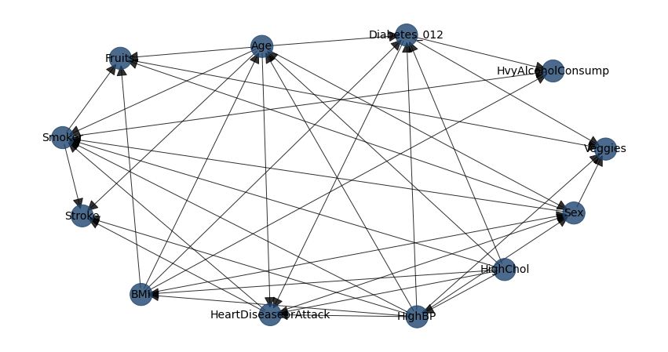

```python
# Hillclimbsearch
model = bn.structure_learning.fit(df_train, methodtype='hc', scoretype='bic')
print(model.get('model'))
G = bn.plot(model)
```

```
[bnlearn] >Compute edge strength with [chi_square]
DAG with 12 nodes and 38 edges
+----+----------------------+----------------------+-------------+--------------+--------------+-------+
|    | source               | target               | stat_test   |      p_value |   chi_square |   dof |
+====+======================+======================+=============+==============+==============+=======+
|  0 | HighBP               | Age                  | True        | 0            |    22009.4   |     3 |
+----+----------------------+----------------------+-------------+--------------+--------------+-------+
|  1 | HighBP               | Diabetes_012         | True        | 0            |    14976.1   |     2 |
+----+----------------------+----------------------+-------------+--------------+--------------+-------+
|  2 | HighBP               | BMI                  | True        | 0            |    10768.3   |     3 |
+----+----------------------+----------------------+-------------+--------------+--------------+-------+
|  3 | HighBP               | HeartDiseaseorAttack | True        | 0            |     9010.54  |     1 |
+----+----------------------+----------------------+-------------+--------------+--------------+-------+
|  4 | HighBP               | Stroke               | True        | 0            |     3362.56  |     1 |
+----+----------------------+----------------------+-------------+--------------+--------------+-------+
|  5 | HighBP               | Veggies              | True        | 1.25683e-172 |      784.513 |     1 |
+----+----------------------+----------------------+-------------+--------------+--------------+-------+
|  6 | HighBP               | Sex                  | True        | 1.55018e-120 |      544.988 |     1 |
+----+----------------------+----------------------+-------------+--------------+--------------+-------+
|  7 | HighBP               | Smoker               | True        | 0            |     1921.65  |     1 |
+----+----------------------+----------------------+-------------+--------------+--------------+-------+
|  8 | HighChol             | HighBP               | True        | 0            |    18083.5   |     1 |
+----+----------------------+----------------------+-------------+--------------+--------------+-------+
|  9 | HighChol             | Age                  | True        | 0            |    14726.4   |     3 |
+----+----------------------+----------------------+-------------+--------------+--------------+-------+
| 10 | HighChol             | Diabetes_012         | True        | 0            |     9078.88  |     2 |
+----+----------------------+----------------------+-------------+--------------+--------------+-------+
| 11 | HighChol             | HeartDiseaseorAttack | True        | 0            |     6638.17  |     1 |
+----+----------------------+----------------------+-------------+--------------+--------------+-------+
| 12 | HighChol             | BMI                  | True        | 0            |     3460.38  |     3 |
+----+----------------------+----------------------+-------------+--------------+--------------+-------+
| 13 | HighChol             | Smoker               | True        | 0            |     1711.41  |     1 |
+----+----------------------+----------------------+-------------+--------------+--------------+-------+
| 14 | BMI                  | Diabetes_012         | True        | 0            |    10283.5   |     6 |
+----+----------------------+----------------------+-------------+--------------+--------------+-------+
| 15 | BMI                  | Age                  | True        | 0            |     2081.33  |     9 |
+----+----------------------+----------------------+-------------+--------------+--------------+-------+
| 16 | BMI                  | Sex                  | True        | 0            |     3485.72  |     3 |
+----+----------------------+----------------------+-------------+--------------+--------------+-------+
| 17 | BMI                  | Fruits               | True        | 0            |     1730.03  |     3 |
```

[output cut: 31 more lines]

```
| 33 | Age                  | Fruits               | True        | 4.98032e-178 |      822.773 |     3 |
+----+----------------------+----------------------+-------------+--------------+--------------+-------+
| 34 | Age                  | Sex                  | True        | 7.35376e-39  |      180.366 |     3 |
+----+----------------------+----------------------+-------------+--------------+--------------+-------+
| 35 | Diabetes_012         | HvyAlcoholConsump    | True        | 1.72902e-152 |      698.891 |     2 |
+----+----------------------+----------------------+-------------+--------------+--------------+-------+
| 36 | Diabetes_012         | HeartDiseaseorAttack | True        | 0            |     6615.28  |     2 |
+----+----------------------+----------------------+-------------+--------------+--------------+-------+
| 37 | Diabetes_012         | Veggies              | True        | 3.06247e-165 |      757.615 |     2 |
+----+----------------------+----------------------+-------------+--------------+--------------+-------+
[bnlearn]> Set node properties.
[bnlearn]> Set edge weights based on the [chi_square] test statistic.
[bnlearn]> Set edge properties.
[bnlearn] >Plot based on Bayesian model
[bnlearn] >Existing coordinates from <pos> are used.
```

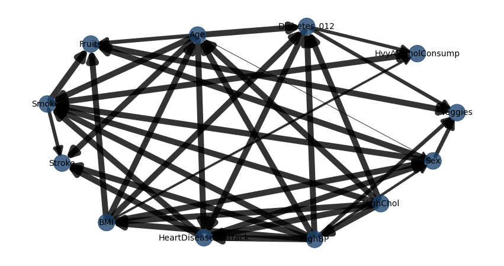

[output not shown]

[output cut: 13 more lines]

[output not shown]

```python
model1 = bn.independence_test(model, df_train, alpha=0.05, prune=False)
print(model1.get('model'))
print(tabulate(model1['independence_test'], tablefmt="grid", headers="keys"))
bn.plot(model1, pos=G['pos'])
```

```python
# Now prune the network.
model2 = bn.independence_test(model, df_train, alpha=0.05, prune=True)
```

```
[bnlearn] >Compute edge strength with [chi_square]
```

```
[bnlearn]> Set node properties.
[bnlearn]> Set edge weights based on the [chi_square] test statistic.
[bnlearn]> Set edge properties.
[bnlearn] >Plot based on Bayesian model
[bnlearn] >Existing coordinates from <pos> are used.
```

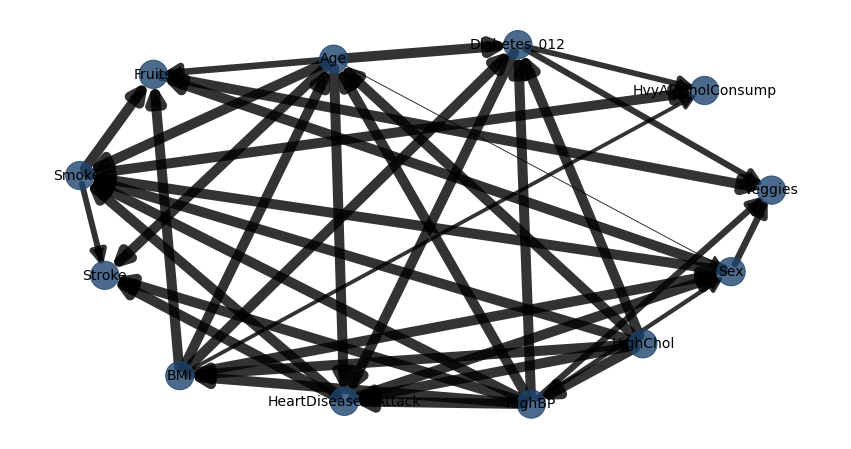

[output not shown]

[output cut: 13 more lines]

[output not shown]

```python
bn.plot(model2, pos=G['pos'])
```

#### Structure

Learn the structure. Interactive plot may be easier to analyse.

```
[bnlearn] >Warning: Computing DAG with 12 nodes can take a very long time!
[bnlearn] >Computing best DAG using [hc]
[bnlearn] >Set scoring type at [bic]
[bnlearn]> Set node properties.
[bnlearn]> Set edge properties.
[bnlearn] >Plot based on Bayesian model
```

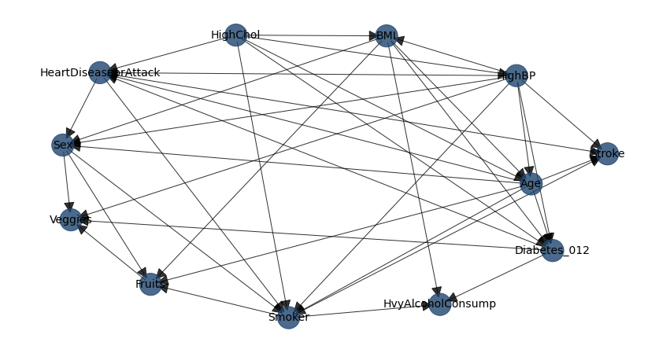

[output not shown]

[output cut: 8 more lines]

[output not shown]

```python
model3 = bn.structure_learning.fit(df_train)
bn.plot(model3, interactive=False)
#bn.plot(model, interactive=True)
```

```
[bnlearn]> Set node properties.
[bnlearn]> Set edge properties.
[bnlearn] >Plot based on Bayesian model
```

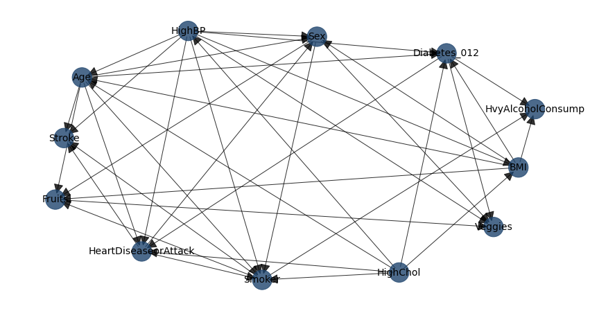

[output not shown]

[output cut: 8 more lines]

[output not shown]

```python
bn.plot(model3)
```

```python
model3 = bn.independence_test(model3, df_train, prune=True)
```

```
[bnlearn] >Compute edge strength with [chi_square]
```

```
[bnlearn]> Set node properties.
[bnlearn]> Set edge weights based on the [chi_square] test statistic.
[bnlearn]> Set edge properties.
[bnlearn] >Plot based on Bayesian model
```

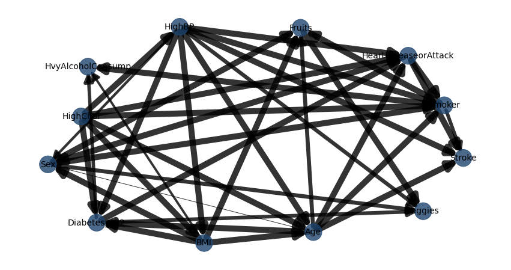

[output not shown]

[output cut: 13 more lines]

[output not shown]

```python
bn.plot(model3, interactive=False)
#bn.plot(model3, interactive=True)
```

```
[bnlearn] >Warning: Computing DAG with 12 nodes can take a very long time!
[bnlearn] >Computing best DAG using [tan]
```

```
[bnlearn]> Set node properties.
[bnlearn]> Set edge properties.
[bnlearn] >Plot based on Bayesian model
```

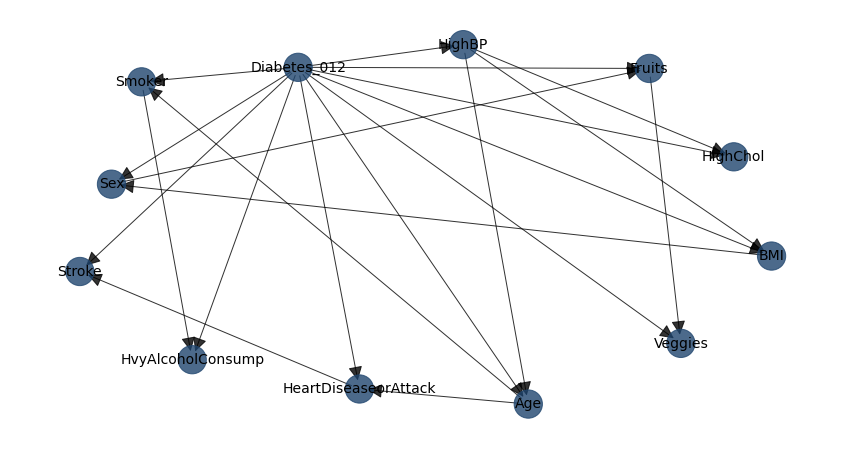

```python
# Apply Tree-augmented Naive Bayes Method
model_nbayes = bn.structure_learning.fit(df_train, methodtype='tan', class_node='Diabetes_012')
G = bn.plot(model_nbayes)
```

```
[bnlearn] >Compute edge strength with [chi_square]
    source                target                stat_test         p_value    chi_square    dof
--  --------------------  --------------------  -----------  ------------  ------------  -----
 0  HighBP                Age                   True         0                22009.4        3
 1  HighBP                HighChol              True         0                18083.5        1
 2  HighBP                BMI                   True         0                10768.3        3
 3  Age                   HeartDiseaseorAttack  True         0                 9147.66       3
 4  Age                   Smoker                True         0                 3099.43       3
 5  BMI                   Sex                   True         0                 3485.72       3
 6  HeartDiseaseorAttack  Stroke                True         0                 8338.06       1
 7  Smoker                HvyAlcoholConsump     True         0                 2053.55       1
 8  Sex                   Fruits                True         0                 1653.97       1
 9  Fruits                Veggies               True         0                13028.2        1
10  Diabetes_012          HighBP                True         0                14976.1        2
11  Diabetes_012          HighChol              True         0                 9078.88       2
12  Diabetes_012          BMI                   True         0                10283.5        6
13  Diabetes_012          Smoker                True         5.65006e-177       811.652      2
14  Diabetes_012          Stroke                True         0                 2342.07       2
15  Diabetes_012          HeartDiseaseorAttack  True         0                 6615.28       2
16  Diabetes_012          Fruits                True         2.44842e-73        334.387      2
17  Diabetes_012          Veggies               True         3.06247e-165       757.615      2
18  Diabetes_012          HvyAlcoholConsump     True         1.72902e-152       698.891      2
19  Diabetes_012          Sex                   True         6.9807e-47         212.557      2
20  Diabetes_012          Age                   True         0                 6802.23       6
[bnlearn]> Set node properties.
[bnlearn]> Set edge weights based on the [chi_square] test statistic.
[bnlearn]> Set edge properties.
[bnlearn] >Plot based on Bayesian model
[bnlearn] >Existing coordinates from <pos> are used.
```

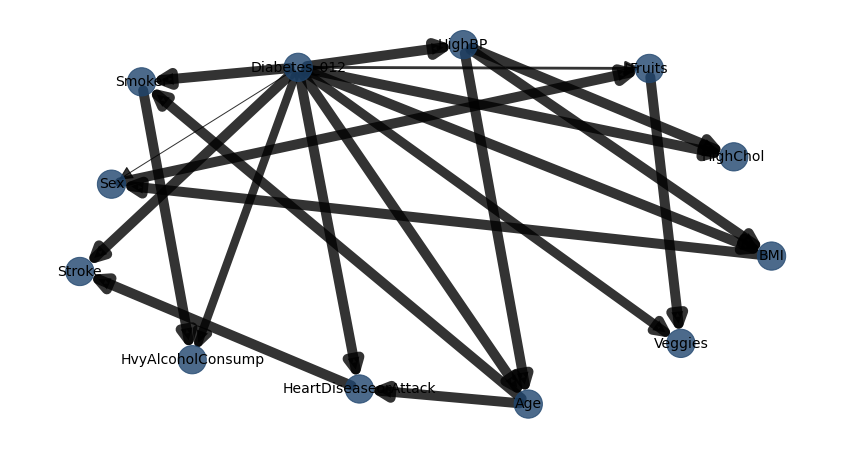

[output not shown]

```python
model_nbayes1 = bn.independence_test(model_nbayes, df_train, alpha=0.05, prune=False)
print(tabulate(model_nbayes1['independence_test'], headers="keys"))
bn.plot(model_nbayes1, pos=G['pos'])
```

#### Manually created DAG

Create a custom Directed Acyclic Graph.

```python
edges = [('Sex', 'Smoker'),
         ('Sex', 'Diabetes_012'),
         ('Sex', 'HeartDiseaseorAttack'),
         ('Sex', 'BMI'),
         ('Veggies', 'HighBP'),
         ('Veggies', 'HeartDiseaseorAttack'),
         ('Veggies', 'BMI'),
         ('Stroke', 'HighChol'),
         ('Stroke', 'Age'),
         ('Stroke', 'HighBP'),
         ('Stroke', 'HeartDiseaseorAttack'),
         ('Stroke', 'BMI'),
         ('Stroke', 'Diabetes_012'),
         ('HighChol', 'Diabetes_012'),
         ('HighChol', 'HighBP'),
         ('HighChol', 'Age'),
         ('Age', 'BMI'),
         ('HighBP', 'HeartDiseaseorAttack'),
         ('HighBP', 'Age'),
         ('HighBP', 'Diabetes_012'),
         ('HighBP', 'BMI'),
         ('Smoker', 'BMI'),
         ('Smoker', 'Age'),
         ('Diabetes_012', 'BMI'),
         ('Diabetes_012', 'Age'),
         ('Diabetes_012', 'HeartDiseaseorAttack'),
         ('Diabetes_012', 'Smoker'),
         ('Fruits', 'BMI'),
         ('HeartDiseaseorAttack', 'Age'),
         ('HeartDiseaseorAttack', 'BMI'),
         ('HvyAlcoholConsump', 'Age'),
         ('HvyAlcoholConsump', 'BMI'),
         ('HvyAlcoholConsump', 'Smoker')]
```

```
[bnlearn] >bayes DAG created.
[bnlearn]> Set node properties.
[bnlearn]> Set edge properties.
[bnlearn] >Plot based on Bayesian model
```

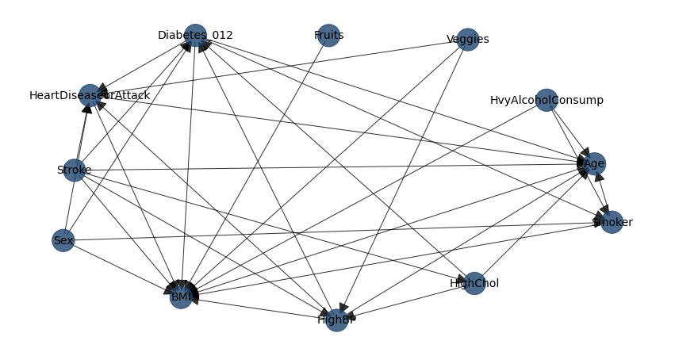

[output not shown]

```python
# Create the DAG from the edges. Plot it.
DAG = bn.make_DAG(edges)

bn.plot(DAG)
#bn.plot(DAG, interactive=True)
```

#### Compute Conditional Probability Distributions (CPDs).

Now using the data set in the dataframe (df) estimate conditional distributions (CPDs). Do it using the method parameter_learning.fit().

Check first if there are any conditional distributions in the model.

```python
bn.print_CPD(DAG)
```

```
[bnlearn] >No CPDs to print. Hint: Add CPDs as following: <bn.make_DAG(DAG, CPD=[cpd_A, cpd_B, etc])> and use bnlearn.plot(DAG) to make a plot.
```

```python
DAG = bn.parameter_learning.fit(DAG, df_train, methodtype='bayes')
```

[output not shown]

[output cut: 86 more lines]

[output not shown]

```python
bn.print_CPD(DAG)
```

[output not shown]

[output cut: 4946 more lines]

[output not shown]

Predictionn & Accuracy

Model 1 from Hill climbing

```python
df_acc=df_new.copy()
X_acc = df_acc.drop('Diabetes_012',axis=1)
y_acc = df_acc['Diabetes_012']
X_train_acc, X_test_acc, y_train_acc, y_test_acc = train_test_split(X_acc, y_acc, test_size=0.2, random_state=101)
```

```python
df_acc.head()
```

|  | Diabetes_012 | HighBP | HighChol | BMI | Smoker | Stroke | HeartDiseaseorAttack | Fruits | Veggies | HvyAlcoholConsump | Sex | Age |
| --- | --- | --- | --- | --- | --- | --- | --- | --- | --- | --- | --- | --- |
| 0 | 0.0 | True | True | obese | True | False | False | False | True | False | fem | Old Adult |
| 1 | 0.0 | False | False | healthy weight | True | False | False | False | False | False | fem | Old Adult |
| 2 | 0.0 | True | True | overweight | False | False | False | True | False | False | fem | Old Adult |
| 3 | 0.0 | True | False | overweight | False | False | False | True | True | False | fem | Senior |
| 4 | 0.0 | True | True | healthy weight | False | False | False | True | True | False | fem | Senior |

```python
df_train_acc=pd.concat([X_train_acc,y_train_acc],axis=1)
```

```python
df_test_acc=pd.concat([X_test_acc,y_test_acc],axis=1)
```

```python
from sklearn.metrics import accuracy_score
```

```
[bnlearn] >Warning: Computing DAG with 12 nodes can take a very long time!
[bnlearn] >Computing best DAG using [hc]
[bnlearn] >Set scoring type at [bic]
[bnlearn]> Set node properties.
[bnlearn]> Set edge properties.
[bnlearn] >Plot based on Bayesian model
```

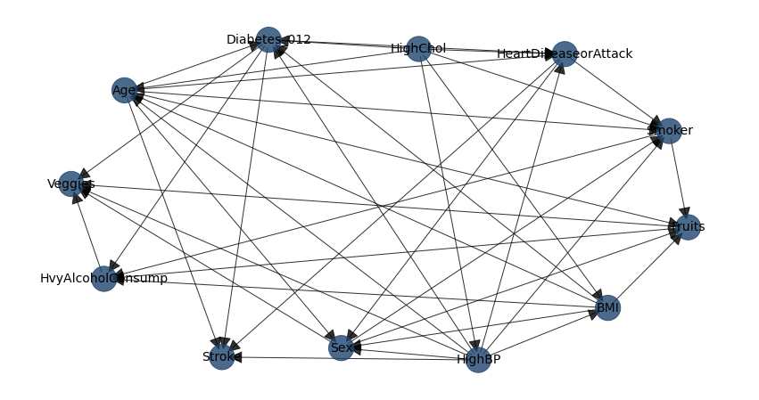

```
[bnlearn] >Parameter learning> Computing parameters using [bayes]
[bnlearn] >Conversion of adjmat to BayesianNetwork.
[bnlearn] >CPD of HighBP:
+---------------+--------------------+--------------------+
| HighChol      | HighChol(False)    | HighChol(True)     |
+---------------+--------------------+--------------------+
| HighBP(False) | 0.6960594782875295 | 0.3984374097060897 |
+---------------+--------------------+--------------------+
| HighBP(True)  | 0.3039405217124705 | 0.6015625902939102 |
+---------------+--------------------+--------------------+
[bnlearn] >CPD of BMI:
+---------------------+-----+----------------------+
| HighBP              | ... | HighBP(True)         |
+---------------------+-----+----------------------+
| HighChol            | ... | HighChol(True)       |
+---------------------+-----+----------------------+
| BMI(healthy weight) | ... | 0.21897634920939885  |
+---------------------+-----+----------------------+
| BMI(obese)          | ... | 0.39590578109089514  |
+---------------------+-----+----------------------+
| BMI(overweight)     | ... | 0.37661626544217947  |
+---------------------+-----+----------------------+
| BMI(underweight)    | ... | 0.008501604257526562 |
+---------------------+-----+----------------------+
[bnlearn] >CPD of Smoker:
+----------------------+-----+----------------------------+
| Age                  | ... | Age(Young Adult)           |
+----------------------+-----+----------------------------+
| HeartDiseaseorAttack | ... | HeartDiseaseorAttack(True) |
+----------------------+-----+----------------------------+
| HighBP               | ... | HighBP(True)               |
+----------------------+-----+----------------------------+
| HighChol             | ... | HighChol(True)             |
+----------------------+-----+----------------------------+
| Sex                  | ... | Sex(male)                  |
+----------------------+-----+----------------------------+
| Smoker(False)        | ... | 0.3787878787878788         |
+----------------------+-----+----------------------------+
| Smoker(True)         | ... | 0.6212121212121212         |
+----------------------+-----+----------------------------+
```

[output cut: 109 more lines]

```
+--------------------------+-----+--------------------+
| BMI                      | ... | BMI(underweight)   |
+--------------------------+-----+--------------------+
| Diabetes_012             | ... | Diabetes_012(1.0)  |
+--------------------------+-----+--------------------+
| Fruits                   | ... | Fruits(True)       |
+--------------------------+-----+--------------------+
| Smoker                   | ... | Smoker(True)       |
+--------------------------+-----+--------------------+
| HvyAlcoholConsump(False) | ... | 0.7557377049180328 |
+--------------------------+-----+--------------------+
| HvyAlcoholConsump(True)  | ... | 0.2442622950819672 |
+--------------------------+-----+--------------------+
CPU times: user 1min 21s, sys: 1.33 s, total: 1min 23s
Wall time: 1min 22s
```

```python
%%time
# Structure learning
DAG_hc = bn.structure_learning.fit(df_train_acc, methodtype='hc',bw_list_method='nodes', verbose=3)

# Plot
G_hc = bn.plot(DAG_hc)

# Parameter learning
model_hc = bn.parameter_learning.fit(DAG_hc, df_train_acc, verbose=3);
```

```python
# About the model
model_hc
```

```
{'model': <pgmpy.models.BayesianNetwork.BayesianNetwork at 0x7ff995252f90>,
 'adjmat': target                HighBP  HighChol    BMI  Smoker  Stroke  \
 source
 HighBP                 False     False   True    True    True
 HighChol                True     False   True    True   False
 BMI                    False     False  False   False   False
 Smoker                 False     False  False   False   False
 Stroke                 False     False  False   False   False
 HeartDiseaseorAttack   False     False  False    True    True
 Fruits                 False     False  False   False   False
 Veggies                False     False  False   False   False
 HvyAlcoholConsump      False     False  False   False   False
 Sex                    False     False  False    True   False
 Age                    False     False  False    True    True
 Diabetes_012           False     False  False   False    True

 target                HeartDiseaseorAttack  Fruits  Veggies  \
 source
 HighBP                                True   False     True
 HighChol                              True   False    False
 BMI                                  False    True    False
 Smoker                               False    True    False
 Stroke                               False   False    False
 HeartDiseaseorAttack                 False   False    False
 Fruits                               False   False     True
 Veggies                              False   False    False
 HvyAlcoholConsump                    False   False     True
 Sex                                  False    True     True
 Age                                   True    True    False
 Diabetes_012                          True   False     True

 target                HvyAlcoholConsump    Sex    Age  Diabetes_012
 source
 HighBP                            False   True   True          True
 HighChol                          False  False   True          True
 BMI                                True   True   True          True
 Smoker                             True  False  False         False
 Stroke                            False  False  False         False
 HeartDiseaseorAttack              False   True  False         False
 Fruits                             True  False  False         False
```

[output cut: 31 more lines]

```
  ('Age', 'Sex'),
  ('Age', 'Diabetes_012'),
  ('Diabetes_012', 'Stroke'),
  ('Diabetes_012', 'HeartDiseaseorAttack'),
  ('Diabetes_012', 'Veggies'),
  ('Diabetes_012', 'HvyAlcoholConsump'),
  ('HighChol', 'HighBP'),
  ('HighChol', 'BMI'),
  ('HighChol', 'Smoker'),
  ('HighChol', 'HeartDiseaseorAttack'),
  ('HighChol', 'Age'),
  ('HighChol', 'Diabetes_012'),
  ('Fruits', 'Veggies'),
  ('Fruits', 'HvyAlcoholConsump'),
  ('HvyAlcoholConsump', 'Veggies')]}
```

```python
# Get score
def get_acc(model, df, col):
    # Get accuracy score by the model for the validation dataset df with target col
    pred = bn.predict(model, df, variables=[col])
    print(pred)
    acc = accuracy_score(df[col], pred[col])
    print('Accuracy -', acc)
    return acc
```

```python
acc1 = get_acc(model_hc, df_test_acc, 'Diabetes_012')
```

```
[bnlearn]> Remaining columns for inference: 11
```

```
       Diabetes_012         p
0                 0  0.918623
1                 0  0.935314
2                 0  0.827057
3                 0  0.918361
4                 0  0.900547
...             ...       ...
50731             0  0.964985
50732             0  0.956814
50733             0  0.703186
50734             0  0.960648
50735             0  0.889340

[50736 rows x 2 columns]
Accuracy - 0.8605329549038159
```

Model 2 from naive bayes

```
[bnlearn] >Warning: Computing DAG with 12 nodes can take a very long time!
[bnlearn] >Computing best DAG using [tan]
```

```
[bnlearn]> Set node properties.
[bnlearn]> Set edge properties.
[bnlearn] >Plot based on Bayesian model
```

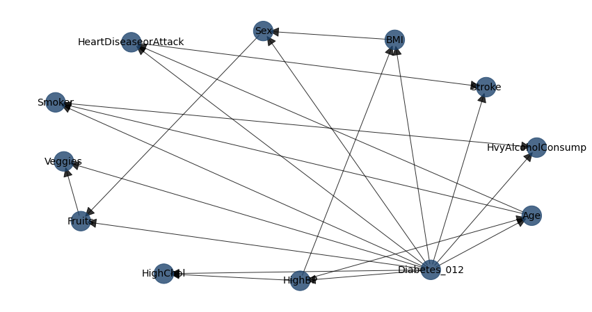

```
[bnlearn] >Parameter learning> Computing parameters using [bayes]
[bnlearn] >Conversion of adjmat to BayesianNetwork.
[bnlearn] >CPD of HighBP:
+---------------+---------------------+--------------------+
| Diabetes_012  | Diabetes_012(0.0)   | Diabetes_012(1.0)  |
+---------------+---------------------+--------------------+
| HighBP(False) | 0.6219191371586726  | 0.2516284092096555 |
+---------------+---------------------+--------------------+
| HighBP(True)  | 0.37808086284132736 | 0.7483715907903445 |
+---------------+---------------------+--------------------+
[bnlearn] >CPD of Age:
+------------------+-----+----------------------+
| Diabetes_012     | ... | Diabetes_012(1.0)    |
+------------------+-----+----------------------+
| HighBP           | ... | HighBP(True)         |
+------------------+-----+----------------------+
| Age(Mid Adult)   | ... | 0.04279730044216896  |
+------------------+-----+----------------------+
| Age(Old Adult)   | ... | 0.40491040260646965  |
+------------------+-----+----------------------+
| Age(Senior)      | ... | 0.5466371887363277   |
+------------------+-----+----------------------+
| Age(Young Adult) | ... | 0.005655108215033744 |
+------------------+-----+----------------------+
[bnlearn] >CPD of HighChol:
+-----------------+-----+---------------------+
| Diabetes_012    | ... | Diabetes_012(1.0)   |
+-----------------+-----+---------------------+
| HighBP          | ... | HighBP(True)        |
+-----------------+-----+---------------------+
| HighChol(False) | ... | 0.27968350011636023 |
+-----------------+-----+---------------------+
| HighChol(True)  | ... | 0.7203164998836398  |
+-----------------+-----+---------------------+
[bnlearn] >CPD of BMI:
+---------------------+-----+----------------------+
| Diabetes_012        | ... | Diabetes_012(1.0)    |
+---------------------+-----+----------------------+
| HighBP              | ... | HighBP(True)         |
+---------------------+-----+----------------------+
```

[output cut: 71 more lines]

```
+----------------+-----+---------------------+
| Fruits         | ... | Fruits(True)        |
+----------------+-----+---------------------+
| Veggies(False) | ... | 0.16798618965414608 |
+----------------+-----+---------------------+
| Veggies(True)  | ... | 0.8320138103458539  |
+----------------+-----+---------------------+
[bnlearn] >CPD of Diabetes_012:
+-------------------+----------+
| Diabetes_012(0.0) | 0.859231 |
+-------------------+----------+
| Diabetes_012(1.0) | 0.140769 |
+-------------------+----------+
CPU times: user 1min 9s, sys: 777 ms, total: 1min 9s
Wall time: 1min 8s
```

```python
%%time
# Structure learning
# Apply Tree-augmented Naive Bayes Method

DAG_nb = bn.structure_learning.fit(df_train_acc, methodtype='tan', class_node='Diabetes_012')


# Plot
G_nb = bn.plot(model_nbayes)

# Parameter learning
model_nb = bn.parameter_learning.fit(DAG_nb, df_train_acc, verbose=3);
```

```python
acc2 = get_acc(model_nb, df_test_acc, 'Diabetes_012')
```

```
[bnlearn]> Remaining columns for inference: 11
```

```
       Diabetes_012         p
0                 0  0.933847
1                 0  0.940269
2                 0  0.873598
3                 0  0.946950
4                 0  0.929506
...             ...       ...
50731             0  0.972192
50732             0  0.970535
50733             0  0.798285
50734             0  0.922882
50735             0  0.879864

[50736 rows x 2 columns]
Accuracy - 0.8557040365815201
```

Chow-Liu

```
[bnlearn] >Warning: Computing DAG with 12 nodes can take a very long time!
[bnlearn] >Computing best DAG using [chow-liu]
```

```
[bnlearn]> Set node properties.
[bnlearn]> Set edge properties.
[bnlearn] >Plot based on Bayesian model
```

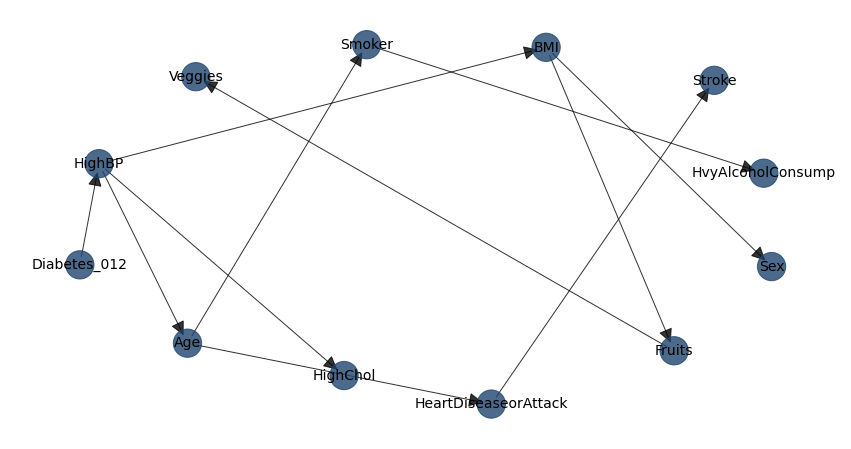

```
[bnlearn] >Parameter learning> Computing parameters using [bayes]
[bnlearn] >Conversion of adjmat to BayesianNetwork.
[bnlearn] >CPD of Diabetes_012:
+-------------------+----------+
| Diabetes_012(0.0) | 0.859231 |
+-------------------+----------+
| Diabetes_012(1.0) | 0.140769 |
+-------------------+----------+
[bnlearn] >CPD of HighBP:
+---------------+---------------------+--------------------+
| Diabetes_012  | Diabetes_012(0.0)   | Diabetes_012(1.0)  |
+---------------+---------------------+--------------------+
| HighBP(False) | 0.6219191371586726  | 0.2516284092096555 |
+---------------+---------------------+--------------------+
| HighBP(True)  | 0.37808086284132736 | 0.7483715907903445 |
+---------------+---------------------+--------------------+
[bnlearn] >CPD of Age:
+------------------+---------------------+----------------------+
| HighBP           | HighBP(False)       | HighBP(True)         |
+------------------+---------------------+----------------------+
| Age(Mid Adult)   | 0.2282412267869129  | 0.07384485627664182  |
+------------------+---------------------+----------------------+
| Age(Old Adult)   | 0.4495895220556598  | 0.4121703252866489   |
+------------------+---------------------+----------------------+
| Age(Senior)      | 0.2386279538061718  | 0.4999430121498097   |
+------------------+---------------------+----------------------+
| Age(Young Adult) | 0.08354129735125553 | 0.014041806286899633 |
+------------------+---------------------+----------------------+
[bnlearn] >CPD of HighChol:
+-----------------+--------------------+---------------------+
| HighBP          | HighBP(False)      | HighBP(True)        |
+-----------------+--------------------+---------------------+
| HighChol(False) | 0.7033371770820783 | 0.40676787708860473 |
+-----------------+--------------------+---------------------+
| HighChol(True)  | 0.2966628229179216 | 0.5932321229113953  |
+-----------------+--------------------+---------------------+
[bnlearn] >CPD of BMI:
+---------------------+----------------------+---------------------+
| HighBP              | HighBP(False)        | HighBP(True)        |
+---------------------+----------------------+---------------------+
```

[output cut: 49 more lines]

```
+--------------------------+---------------------+---------------------+
| Smoker                   | Smoker(False)       | Smoker(True)        |
+--------------------------+---------------------+---------------------+
| HvyAlcoholConsump(False) | 0.9628213486511726  | 0.9160972157721312  |
+--------------------------+---------------------+---------------------+
| HvyAlcoholConsump(True)  | 0.03717865134882738 | 0.08390278422786882 |
+--------------------------+---------------------+---------------------+
[bnlearn] >CPD of Veggies:
+----------------+---------------------+---------------------+
| Fruits         | Fruits(False)       | Fruits(True)        |
+----------------+---------------------+---------------------+
| Veggies(False) | 0.31998128217126814 | 0.11459631898040248 |
+----------------+---------------------+---------------------+
| Veggies(True)  | 0.6800187178287319  | 0.8854036810195975  |
+----------------+---------------------+---------------------+
```

```python
# Structure learning
DAG_cl = bn.structure_learning.fit(df_train_acc, methodtype='cl', root_node='Diabetes_012', bw_list_method='nodes')
# Plot detected DAG
G_cl = bn.plot(DAG_cl)
# Parameter learning
model_cl = bn.parameter_learning.fit(DAG_cl, df_train_acc, verbose=3);
```

```python
acc3 = get_acc(model_cl, df_test_acc, 'Diabetes_012')
```

```
[bnlearn]> Remaining columns for inference: 11
```

```
       Diabetes_012         p
0                 0  0.937835
1                 0  0.755123
2                 0  0.755123
3                 0  0.937835
4                 0  0.755123
...             ...       ...
50731             0  0.937835
50732             0  0.937835
50733             0  0.937835
50734             0  0.755123
50735             0  0.755123

[50736 rows x 2 columns]
Accuracy - 0.8593306527909177
```

Manuuly Built Model

```
[bnlearn] >bayes DAG created.
[bnlearn]> Set node properties.
[bnlearn]> Set edge properties.
[bnlearn] >Plot based on Bayesian model
```

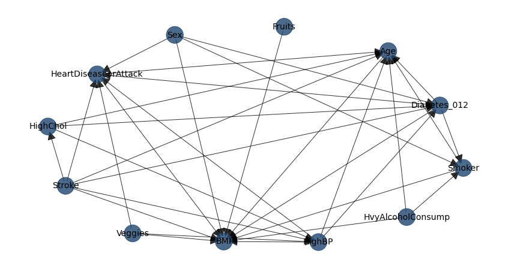

```
[bnlearn] >Parameter learning> Computing parameters using [bayes]
[bnlearn] >CPD of Sex:
+-----------+----------+
| Sex(fem)  | 0.554428 |
+-----------+----------+
| Sex(male) | 0.445572 |
+-----------+----------+
[bnlearn] >CPD of Smoker:
+-------------------+-----+-------------------------+
| Diabetes_012      | ... | Diabetes_012(1.0)       |
+-------------------+-----+-------------------------+
| HvyAlcoholConsump | ... | HvyAlcoholConsump(True) |
+-------------------+-----+-------------------------+
| Sex               | ... | Sex(male)               |
+-------------------+-----+-------------------------+
| Smoker(False)     | ... | 0.42329545454545453     |
+-------------------+-----+-------------------------+
| Smoker(True)      | ... | 0.5767045454545454      |
+-------------------+-----+-------------------------+
[bnlearn] >CPD of Diabetes_012:
+-------------------+-----+---------------------+
| HighBP            | ... | HighBP(True)        |
+-------------------+-----+---------------------+
| HighChol          | ... | HighChol(True)      |
+-------------------+-----+---------------------+
| Sex               | ... | Sex(male)           |
+-------------------+-----+---------------------+
| Stroke            | ... | Stroke(True)        |
+-------------------+-----+---------------------+
| Diabetes_012(0.0) | ... | 0.5871632329635499  |
+-------------------+-----+---------------------+
| Diabetes_012(1.0) | ... | 0.41283676703645006 |
+-------------------+-----+---------------------+
[bnlearn] >CPD of HeartDiseaseorAttack:
+-----------------------------+-----+---------------------+
| Diabetes_012                | ... | Diabetes_012(1.0)   |
+-----------------------------+-----+---------------------+
| HighBP                      | ... | HighBP(True)        |
+-----------------------------+-----+---------------------+
| Sex                         | ... | Sex(male)           |
```

[output cut: 92 more lines]

```
+----------------------+-----+----------------------------+
| Age(Young Adult)     | ... | 0.1524390243902439         |
+----------------------+-----+----------------------------+
[bnlearn] >CPD of Fruits:
+---------------+----------+
| Fruits(False) | 0.359243 |
+---------------+----------+
| Fruits(True)  | 0.640757 |
+---------------+----------+
[bnlearn] >CPD of HvyAlcoholConsump:
+--------------------------+-----------+
| HvyAlcoholConsump(False) | 0.926707  |
+--------------------------+-----------+
| HvyAlcoholConsump(True)  | 0.0732932 |
+--------------------------+-----------+
```

```python
DAG = bn.make_DAG(edges)
G = bn.plot(DAG)
model_mb = bn.parameter_learning.fit(DAG, df_train_acc, verbose=3);
```

```python
acc4 = get_acc(model_mb, df_test_acc, 'Diabetes_012')
```

```
[bnlearn]> Remaining columns for inference: 11
```

[output not shown]

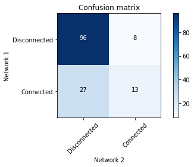

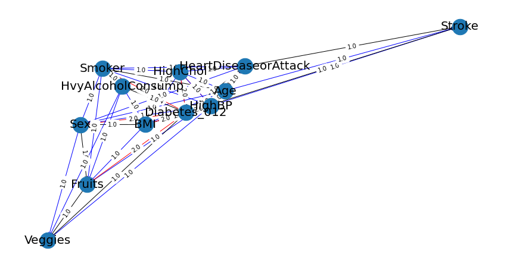

```
Coincidence - 0.7569444444444444
```

```python
# Models comparing
res = bn.bnlearn.compare_networks(model_hc, model_nb, figsize=(15, 8), verbose=3)
print('Coincidence -', (res[0][0, 0] + res[0][1, 1])/res[0].sum())
```

Convert to HTML

```python
%%shell
jupyter nbconvert --to html /content/1031_Capstone_II.ipynb
```

```
[NbConvertApp] Converting notebook /content/1031_Capstone_II.ipynb to html
[NbConvertApp] Writing 3490088 bytes to /content/1031_Capstone_II.html
```